# 北京自如[2018.1.1-2018.3.15]签约房源的均价分析

季康

2018年3月23日

## 背景介绍：

数据来源：商家=自如；城市=北京；时间范围：sign_time:2018年；pt=20180315  
模型目标：对原始数据集中出现的所有小区，求整租均值和合租均值两个均值。  
遇到的主要难题：我们的来源数据，可能不会覆盖所有的小区的整租与合租类型。会造成均值统计数据的缺失。  
解决方法就是：在北京市范围内，以小区为统计单元，建立整租均价和合租均价的回归关系。实现二者的相互预测和插补。  
本案例对均价模型的助益：在某小区的整租与合租数据历史数据<知一缺一>的情况下，可以通过回归关系补全缺失数据。  
不足：如果历史数据对某小区的数据完全缺失，本例这种基于租赁类型维度的插补策略失效。

## step 1：在adhoc中提取数据：

在adhoc中的使用的sql查询语句如下：导出数据存为：625703.csv

```sql
SELECT hdic_city_id, hdic_district_id, hdic_bizcircle_id, hdic_resblock_id,
case frame_bedroom_num when '1' then '1' when '2' then '2' when '3' then '3' else '0' end as frame_bedroom_num ,
case rent_type when '1' then '1' when '2' then '2' else '0' end as rent_type, case decoration when '1' then '1' when '2' then '2' when '3' then '3' else'0' end as decoration,
appid,
price_trans,
price_listing,
price_trans/rent_area as price_trans_per_area,
price_listing/rent_area as price_listing_per_area,
to_date(sign_time) as sign_date,
to_date(app_ctime) as appc_date,
datediff(to_date(sign_time),to_date(app_ctime)) as diff_days,
pt
FROM ods.ods_lianjia_house_rent_new_da
WHERE hdic_city_id = 110000 and appid = 500 and pt='20180315000000'
and sign_time like '2018%' and from_unixtime(unix_timestamp(app_ctime,'yyyy-mm-dd ss:ss:ss'),'yyyymmddssssss')> '201701010000000'
```

## step 2：读入数据。

读入在adhoc中导出的数据：625703.csv 数据的维数是：17202行 16列  
数据框ziru0的部分数据如下：

```r
setwd("C:/Users/lianjia/Desktop/junjia_model_lianjia")
ziru0 = read.csv('625703.csv')
dim(ziru0)# 17202    16
```

```
## [1] 17202    16
```

```r
head(ziru0)
```

```
##   hdic_city_id hdic_district_id hdic_bizcircle_id hdic_resblock_id
## 1       110000         23008613          18335726      1.11103e+12
## 2       110000         23008615          18335749      1.11103e+12
## 3       110000         23008613          18335711      1.11103e+12
## 4       110000         23008625          18335699      1.11104e+12
## 5       110000         23008618          18335767      1.11103e+12
## 6       110000         23008618          18335768      1.11103e+12
##   frame_bedroom_num rent_type decoration appid price_trans price_listing
## 1                 2         1          3   500        5690          5690
## 2                 2         1          3   500        4260          4260
## 3                 3         2          3   500        2590          2590
## 4                 2         1          3   500        5560          5560
## 5                 1         1          3   500        5790          5790
## 6                 2         2          3   500        3330          3330
##   price_trans_per_area price_listing_per_area sign_date appc_date
## 1           99.8245614             99.8245614 2018/1/19 2017/7/23
## 2          62.64705882            62.64705882 2018/2/21 2017/7/24
## 3               323.75                 323.75  2018/3/6 2017/7/18
## 4          62.47191011            62.47191011 2018/1/23 2017/7/20
## 5          141.2195122            141.2195122  2018/3/8 2017/7/19
## 6                  370                    370  2018/3/8 2017/7/12
##   diff_days          pt
## 1       180 2.01803e+13
## 2       212 2.01803e+13
## 3       231 2.01803e+13
## 4       187 2.01803e+13
## 5       232 2.01803e+13
## 6       239 2.01803e+13
```

## step 3：数据类型转换：

将价格转换成数值型变量。  
将装修情况和租赁类型转换成因子型变量。  
添加出租面积area这个字段。  
在数据框ziru0中删除价格price_listing_per_area缺失或者price_trans_per_area缺失的观测。  
以保证我们的源数据的单位价格变量没有缺失。

```r
##要变成数值型的变量:numeric_names
numeric_names = names(ziru0)[grep('per_area',names(ziru0))]
ziru0[,numeric_names] = apply(ziru0[,numeric_names],2,as.numeric)
##要变成因子型的变量：factor_names
ziru0$decoration = as.factor(ziru0$decoration)
ziru0$rent_type = as.factor(ziru0$rent_type)
##增加新的一列：area（因为在sql中提数的时候忘记提这个字段了）
ziru0$area = ziru0$price_listing/ziru0$price_listing_per_area
#在数据框ziru0中删除价格price_listing_per_area缺失或者price_trans_per_area缺失的观测。
complete_row = complete.cases(ziru0$price_trans_per_area,ziru0$price_listing_per_area)
ziru0 = ziru0[complete_row,]
```

## 对商圈这个地理维度进行数据挖掘

### 构建新的数据框：shangquan

```r
a = sort(table(ziru0$hdic_bizcircle_id))
#共216个商圈  length(a)=216
#新建一个数据框：shangquan
shangquan = data.frame(number = a)

#依照商圈的租房热门程度,编码离散化变量：商圈热度：
#变量离散化过程中阈值的选择依据：（1-33：冷清）包含25%的商圈,（34-100：一般）包含50%的商圈，（101及以上：热门）包含25%的商圈。
#商圈过去3个月成交量的分位数如下：
summary(shangquan$number.Freq)
```

```
##    Min. 1st Qu.  Median    Mean 3rd Qu.    Max.
##    1.00   32.75   60.00   79.63   98.50  629.00
```

```r
#在数据框shangquan中新增加一列：shangquan_degree
library(dplyr)
shangquan <- shangquan %>%
  mutate(
    shangquan_degree = case_when(
      number.Freq <=33 ~ '冷清商圈',
      number.Freq>34 & number.Freq<100 ~ '一般商圈',
      number.Freq>=100 ~ '热门商圈'
      )
  )
#重命名数据框各列。
shangquan$shangquan_degree=as.factor(shangquan$shangquan_degree)
names(shangquan) = c('hdic_bizcircle_id','shangquan_pinshu','shangquan_degree')
```

### 画图：北京自如的热门商圈展示

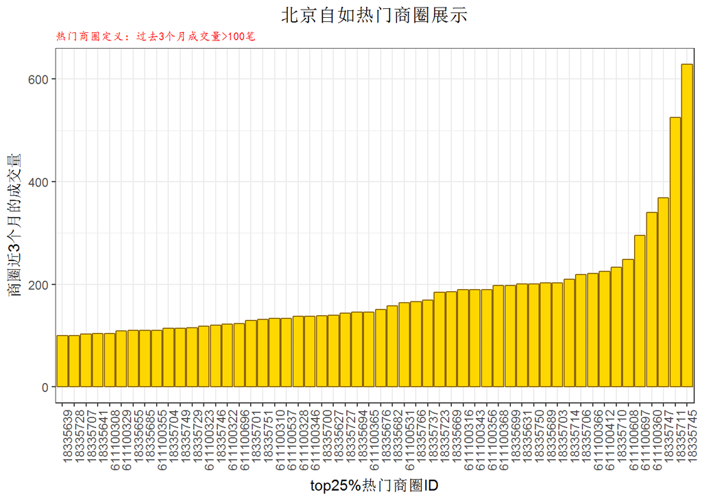

```r
windowsFonts(myFont=windowsFont("楷体"))
library(ggplot2)
ggplot(shangquan[shangquan$shangquan_degree=='热门商圈',],aes(x = hdic_bizcircle_id,y = shangquan_pinshu))+
  geom_bar(stat = 'identity',fill='#FFD700',color = '#8B6508')+
  theme_bw()+
  theme(axis.text.x = element_text(angle=90, hjust=1, vjust=1))+
  labs(x= 'top25%热门商圈ID',y='商圈近3个月的成交量',title = '北京自如热门商圈展示',subtitle = '热门商圈定义：过去3个月成交量>100笔')+
  theme(plot.title = element_text(hjust = 0.5),plot.subtitle = element_text(family = 'myFont',size = 8 ,colour = 'red'))
```

## step :对出租面积area进行描述性的统计分析,来挖掘出租面积对签约价格的影响。

### 1) 出租面积箱线图(整租合租对比）：

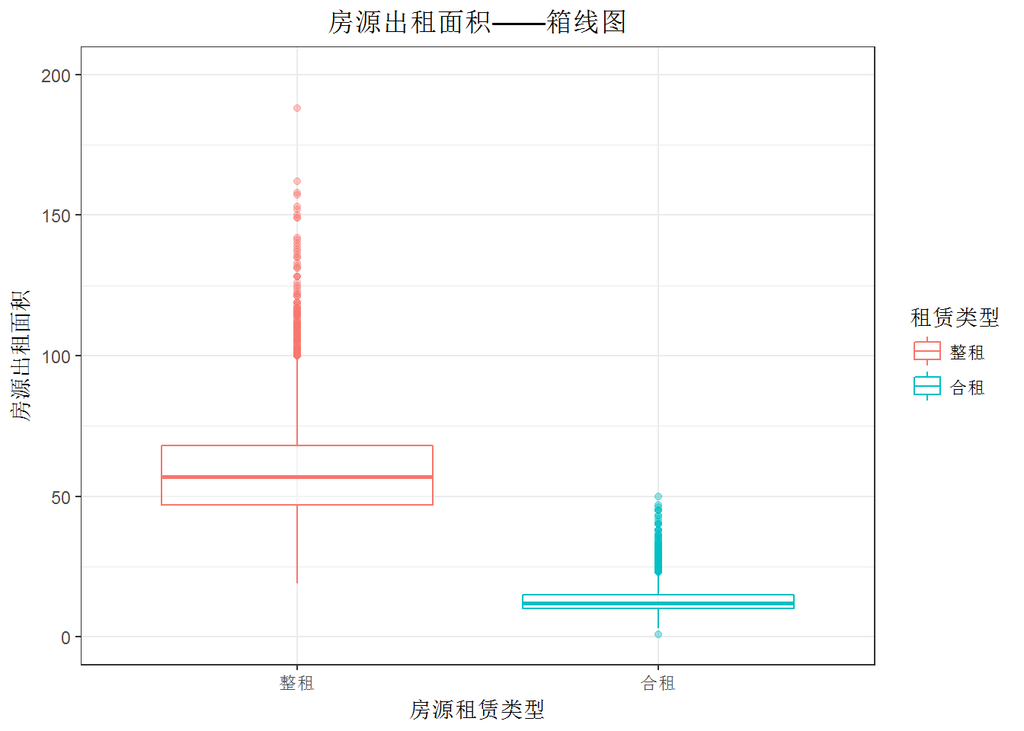

```r
library(ggplot2)
ggplot(data = ziru0,aes(x = rent_type,y=area))+
  geom_boxplot(aes(colour = rent_type),alpha=0.4)+
  labs(x='房源租赁类型',y='房源出租面积',color = '租赁类型',title='房源出租面积——箱线图')+
  scale_x_discrete(labels = c('整租','合租'))+
  scale_y_continuous(limits = c(0,200))+
  scale_color_discrete(labels = c('整租','合租'))+
  theme_bw()+
  theme(plot.title = element_text(hjust = 0.5))
```

### 2)房源签约价格与出租面积散点图（整租合租对比）：

结论：从图中可以看出签约价格（price_listing）与出租面积（area）的线性关系明显。  
整租与合租的房源在这面积和价格维度上有明显的聚类分离现象。 #### 1.用北京所有商圈的房源数据来做图（17000条）

[output not shown]

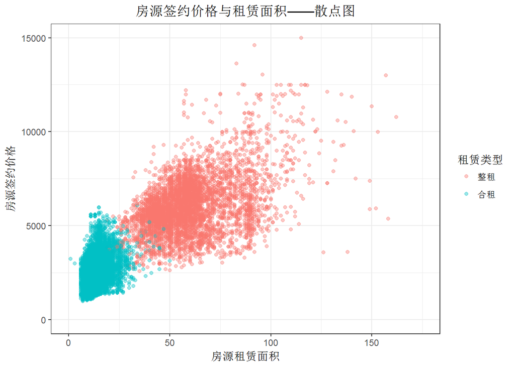

```r
ggplot(data = ziru0,aes(x = area,y=price_listing))+
  geom_point(aes(color = rent_type),alpha=0.4)+
  labs(x='房源租赁面积',y='房源签约价格',color = '租赁类型',title='房源签约价格与租赁面积——散点图')+
  scale_x_continuous(limits = c(0,175))+
  scale_y_continuous(limits = c(0,15000))+
  theme_bw()+
  scale_color_discrete()+
  theme(plot.title = element_text(hjust = 0.5))+
  scale_color_discrete(labels = c('整租','合租'))
```

#### 2.用北京某个商圈内的房源数据来做图（614条）

[output not shown]

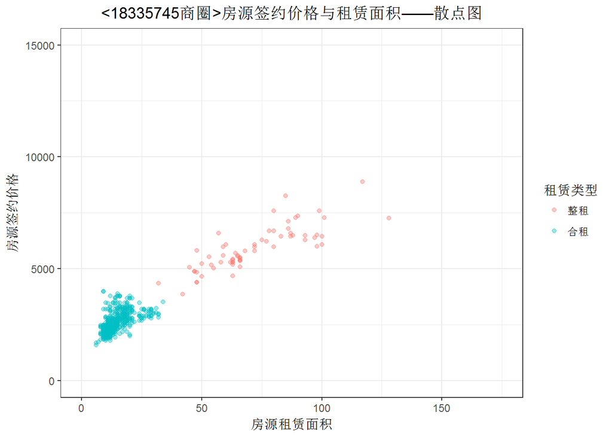

```r
ggplot(data = ziru0[ziru0$hdic_bizcircle_id==18335745,],aes(x = area,y=price_listing))+
  geom_point(aes(color = rent_type),alpha=0.4)+
  labs(x='房源租赁面积',y='房源签约价格',color = '租赁类型',title='<18335745商圈>房源签约价格与租赁面积——散点图')+
  scale_x_continuous(limits = c(0,175))+
  scale_y_continuous(limits = c(0,15000))+
  theme_bw()+
  scale_color_discrete()+
  theme(plot.title = element_text(hjust = 0.5))+
  scale_color_discrete(labels = c('整租','合租'))
```

### 3)房源签约单价与出租面积散点图（整租合租对比）：

结论：很明显：自如房源中：合租方式的签约单价是明显高于整租方式的签约单价的。 #### 1.用北京所有商圈的房源数据来做图（17000条）

[output not shown]

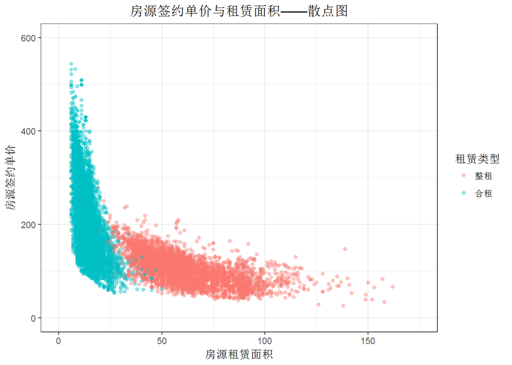

```r
ggplot(data = ziru0,aes(x = area,y=price_listing_per_area))+
  geom_point(aes(color = rent_type),alpha=0.4)+
  labs(x='房源租赁面积',y='房源签约单价',color = '租赁类型',title='房源签约单价与租赁面积——散点图')+
  scale_x_continuous(limits = c(0,175))+
  scale_y_continuous(limits = c(0,600))+
  theme_bw()+
  scale_color_discrete()+
  theme(plot.title = element_text(hjust = 0.5))+
  scale_color_discrete(labels = c('整租','合租'))
```

#### 2.用北京某个商圈内的房源数据来做图（614条）

[output not shown]

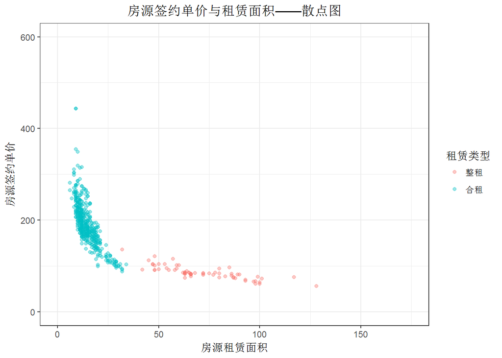

```r
ggplot(data = ziru0[ziru0$hdic_bizcircle_id==18335745,],aes(x = area,y=price_listing_per_area))+
  geom_point(aes(color = rent_type),alpha=0.4)+
  labs(x='房源租赁面积',y='房源签约单价',color = '租赁类型',title='房源签约单价与租赁面积——散点图')+
  scale_x_continuous(limits = c(0,175))+
  scale_y_continuous(limits = c(0,600))+
  theme_bw()+
  scale_color_discrete()+
  theme(plot.title = element_text(hjust = 0.5))+
  scale_color_discrete(labels = c('整租','合租'))
```

## step 4：对数据框ziru0分组

```r
##查看自如房源的装修情况和租赁情况：
str(ziru0$decoration)
```

```
##  Factor w/ 1 level "3": 1 1 1 1 1 1 1 1 1 1 ...
```

```r
summary(ziru0$decoration)#自如房源的装修情况：
```

```
##     3
## 17201
```

```r
summary(ziru0$rent_type)#自如房源的租赁类型情况：
```

```
##     1     2
##  5213 11988
```

```r
library(dplyr)
#按（商圈，小区，租赁方式）对数据框ziru0分组：得到ziru1_group
ziru1_group = group_by(ziru0, hdic_bizcircle_id,hdic_resblock_id,rent_type)
#依这样的分组方式可以分成3937组。
n_groups(ziru1_group)
```

```
## [1] 735
```

```r
#查看各个组包含样本数的统计表：
table(group_size(ziru1_group))
```

```
##
##   1   2   3   4   5   6   7   8   9  10  11  12  13  14  15  16  17  18
##  89  42  51  28  30  34  24  21  16  21  14  15  18  12  13  13   7   8
##  19  20  21  22  23  24  25  26  27  28  29  30  31  32  33  34  35  36
##   4  10   7  10   9  10  13  11   6   9   6   6   7   8   3   2   5   4
##  37  38  39  40  41  42  43  44  45  46  47  48  49  50  51  52  53  54
##   8   9   7   6   5   4   3   6   5   3   3   4   1   4   4   1   3   1
##  55  56  57  58  59  60  63  64  66  67  69  70  71  72  74  76  79  80
##   3   2   5   2   1   1   3   1   2   1   3   2   2   1   2   1   3   1
##  83  86  91  93  95  98 100 102 104 107 108 111 112 115 116 119 122 125
##   1   1   1   2   2   1   2   1   1   1   2   1   1   2   1   1   1   1
## 130 131 141 144 153 154 163 178 183 270 360 395 407
##   1   1   1   1   1   1   1   1   1   1   1   1   1
```

## step 5：对分组数据求聚合：

```r
ziru2 = ziru0 %>%
  group_by(hdic_district_id,hdic_resblock_id,rent_type) %>%
  summarise(n = n(),mean_price = mean(price_trans_per_area))
dim(ziru2)
```

```
## [1] 189   5
```

```r
head(ziru2)
```

```
## # A tibble: 6 x 5
## # Groups:   hdic_district_id, hdic_resblock_id [3]
##   hdic_district_id hdic_resblock_id rent_type     n mean_price
##              <int>            <dbl> <fct>     <int>      <dbl>
## 1         23008611   1111030000000. 1           134       81.0
## 2         23008611   1111030000000. 2          1117      178.
## 3         23008611   1111040000000. 1             5       80.2
## 4         23008611   1111040000000. 2            22      191.
## 5         23008611   1111050000000. 1            28       75.4
## 6         23008611   1111050000000. 2           158      200.
```

## step 6：聚合长表变宽表

```r
library(reshape2)
ziru2_rent_type_junjia = dcast(data = ziru2,formula =hdic_district_id+hdic_resblock_id~rent_type) #长表变宽表。
#改变宽表ziru2_rent_type_junjia中的数据类型：
ziru2_rent_type_junjia$hdic_district_id = as.factor(ziru2_rent_type_junjia$hdic_district_id)
ziru2_rent_type_junjia$hdic_resblock_id =
as.factor(ziru2_rent_type_junjia$hdic_resblock_id)
#修改一下的宽表的列名称，新数据框的3列：小区ID，整租的平均单价，合租的平均单价。
names(ziru2_rent_type_junjia)[3:4]=c('zheng_mean','he_mean')
dim(ziru2_rent_type_junjia)
```

```
## [1] 114   4
```

```r
sum(is.na(ziru2_rent_type_junjia))
```

```
## [1] 39
```

```r
#统计整租与合租的缺失值数目。
sum(is.na(ziru2_rent_type_junjia$zheng_mean))#808个整租均值缺失
```

```
## [1] 23
```

```r
sum(is.na(ziru2_rent_type_junjia$he_mean))#750个合租均值缺失
```

```
## [1] 16
```

```r
head(ziru2_rent_type_junjia)
```

```
##   hdic_district_id hdic_resblock_id zheng_mean  he_mean
## 1         23008611      1.11103e+12   80.98671 177.9772
## 2         23008611      1.11104e+12   80.16858 190.9443
## 3         23008611      1.11105e+12   75.38627 199.9477
## 4         23008611      1.11106e+12   57.78905 162.2189
## 5         23008611       1.1111e+12   60.50859 176.6667
## 6         23008611      1.17801e+14   97.17647 218.1182
```

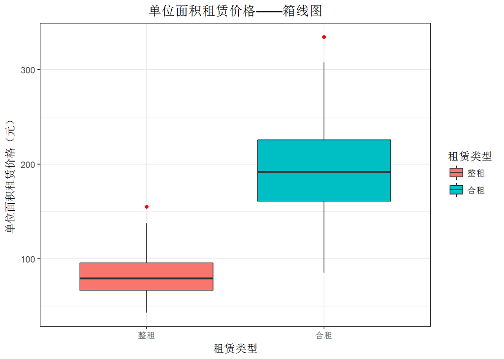

```r
#绘制箱线图与散点图来挖掘整租均值和合租均值这两个变量的关系;

#绘制箱线图如下：
library(ggplot2)
ggplot(data = ziru2,aes(x = rent_type,y =mean_price))+
 geom_boxplot(aes(fill =rent_type ),outlier.colour = '#FF0000')+
  labs(x = "租赁类型",y= '单位面积租赁价格（元）',fill='租赁类型',title='单位面积租赁价格——箱线图')+
  scale_x_discrete(labels = c('整租','合租'))+
  scale_fill_discrete(labels = c('整租','合租'))+
  theme_bw()+
  theme(plot.title = element_text(hjust = 0.5))
```

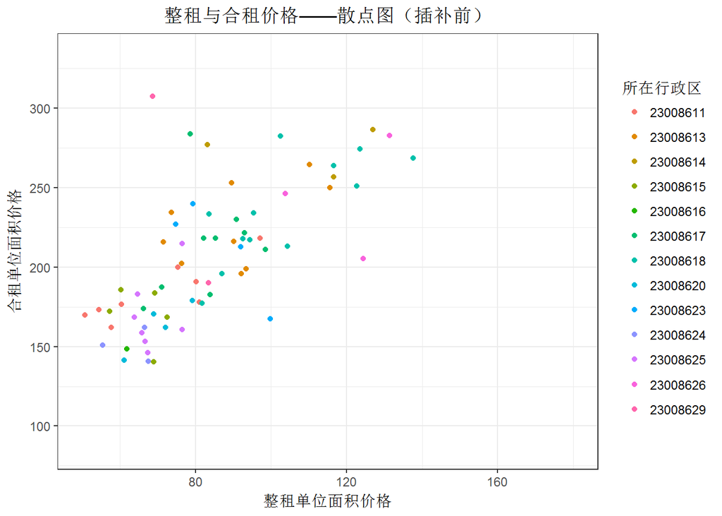

```r
#绘制散点图如下：
ggplot(data = ziru2_rent_type_junjia,aes(x = zheng_mean,y=he_mean))+
 geom_point(aes(color = hdic_district_id))+
  labs(x='整租单位面积价格',y='合租单位面积价格',color = '所在行政区',title='整租与合租价格——散点图（插补前）')+
  scale_x_continuous(limits = c(50,180))+
  #scale_y_continuous(limits = c(50,400))+
  theme_bw()+
  scale_color_discrete()+
  theme(plot.title = element_text(hjust = 0.5))
```

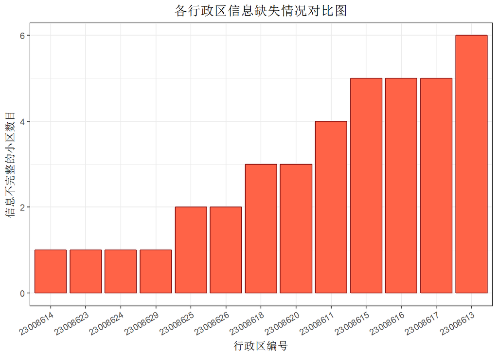

```r
#绘制缺失数据所在的行政区：
indexNA_zheng = which(is.na(ziru2_rent_type_junjia$zheng_mean))
indexNA_he = which(is.na(ziru2_rent_type_junjia$he_mean))

ggplot(data = ziru2_rent_type_junjia[c(indexNA_he,indexNA_zheng),],aes(x=reorder(hdic_district_id,rep(1,length(hdic_district_id)),sum)))+
  geom_bar(fill = '#FF6347',color = '#8B1A1A')+theme_bw()+
  theme(axis.text.x = element_text(angle=30, hjust=1, vjust=1))+
  labs(x='行政区编号',y='信息不完整的小区数目',title = '各行政区信息缺失情况对比图')+
  theme(plot.title = element_text(hjust = 0.5))
```

```r
  #geom_text(aes(label = count))
```

从箱线图可以看出：这两个均价均呈右偏分布。  
从散点图可以看出，整租均价与合租均价呈现明显的线性相关性。

## step 7：建立整租均价和合租均价间的回归模型

```r
#首要问题：谁做因变量？
#首次回归的样本量:1558个观测值。
dim(ziru2_rent_type_junjia)[1]-sum(complete.cases(ziru2_rent_type_junjia))
```

```
## [1] 39
```

```r
#结论：合租的缺失值少，所以将合租作为自变量，整租作为因变量来预测。
#回归建模：
#回归模型1  lm_1：Multiple R-squared:  0.624
lm_1 = lm(formula = sqrt(zheng_mean)~he_mean,data =ziru2_rent_type_junjia,na.action = na.omit )
summary(lm_1)
```

```
##
## Call:
## lm(formula = sqrt(zheng_mean) ~ he_mean, data = ziru2_rent_type_junjia,
##     na.action = na.omit)
##
## Residuals:
##      Min       1Q   Median       3Q      Max
## -2.77757 -0.51755  0.04916  0.52626  2.11598
##
## Coefficients:
##             Estimate Std. Error t value Pr(>|t|)
## (Intercept) 4.963461   0.417150  11.899  < 2e-16 ***
## he_mean     0.019858   0.002023   9.814 5.62e-15 ***
## ---
## Signif. codes:  0 '***' 0.001 '**' 0.01 '*' 0.05 '.' 0.1 ' ' 1
##
## Residual standard error: 0.7901 on 73 degrees of freedom
##   (39 observations deleted due to missingness)
## Multiple R-squared:  0.5689, Adjusted R-squared:  0.563
## F-statistic: 96.32 on 1 and 73 DF,  p-value: 5.625e-15
```

```r
#回归模型2  lm_2：Multiple R-squared: 0.4939
lm_2 = lm(formula = zheng_mean~he_mean,data =ziru2_rent_type_junjia,na.action = na.omit )
summary(lm_2)$r.squared
```

```
## [1] 0.55738
```

```r
#回归模型3  lm_3：Multiple R-squared: 0.5115
lm_3 = lm(formula = zheng_mean~sqrt(he_mean),data =ziru2_rent_type_junjia,na.action = na.omit )
summary(lm_3)$r.squared
```

```
## [1] 0.5665614
```

```r
#模型选择结论：选择R2最大的lm_1模型来预测整租均值。
```

## step 8：对小区均值表中的<整租均价>缺失值进行插补。

先找到两列变量缺失值的位置索引indexNA_zheng和indexNA_he。  
对缺失的zheng_mean进行回归预测,对缺失的zheng_mean进行补缺。

```r
#找到缺失值的位置：
indexNA_zheng = which(is.na(ziru2_rent_type_junjia$zheng_mean))
indexNA_he = which(is.na(ziru2_rent_type_junjia$he_mean))
#对缺失的zheng_mean进行回归预测
predict_lm1 = predict(object = lm_1,newdata= ziru2_rent_type_junjia[indexNA_zheng,])
#对缺失的zheng_mean进行补缺。
ziru2_rent_type_junjia[indexNA_zheng,'zheng_mean']=predict_lm1**2
```

## step 9：再对小区均值表中的<合租均价>缺失值进行插补。

```r
#zheng_mean完整之后，再he_mean进行补缺:由lm_1可知，两变量间是是两次函数关系
lm_4 = lm(formula = he_mean~sqrt(zheng_mean),data =ziru2_rent_type_junjia,na.action = na.omit )
summary(lm_4)$r.squared #Multiple R-squared:  0.5041
```

```
## [1] 0.6729411
```

```r
#选用lm_4模型来对he_mean补缺。
predict_lm4 = predict(object = lm_4,newdata = ziru2_rent_type_junjia[indexNA_he,])
ziru2_rent_type_junjia[indexNA_he,'he_mean']=predict_lm4
head(ziru2_rent_type_junjia)
```

```
##   hdic_district_id hdic_resblock_id zheng_mean  he_mean
## 1         23008611      1.11103e+12   80.98671 177.9772
## 2         23008611      1.11104e+12   80.16858 190.9443
## 3         23008611      1.11105e+12   75.38627 199.9477
## 4         23008611      1.11106e+12   57.78905 162.2189
## 5         23008611       1.1111e+12   60.50859 176.6667
## 6         23008611      1.17801e+14   97.17647 218.1182
```

```r
#现在均值表中已经没有缺失的均价数据。
sum(is.na(ziru2_rent_type_junjia))
```

```
## [1] 0
```

## step 10：将插补后效果可视化：

回归插补之后的散点图如下：

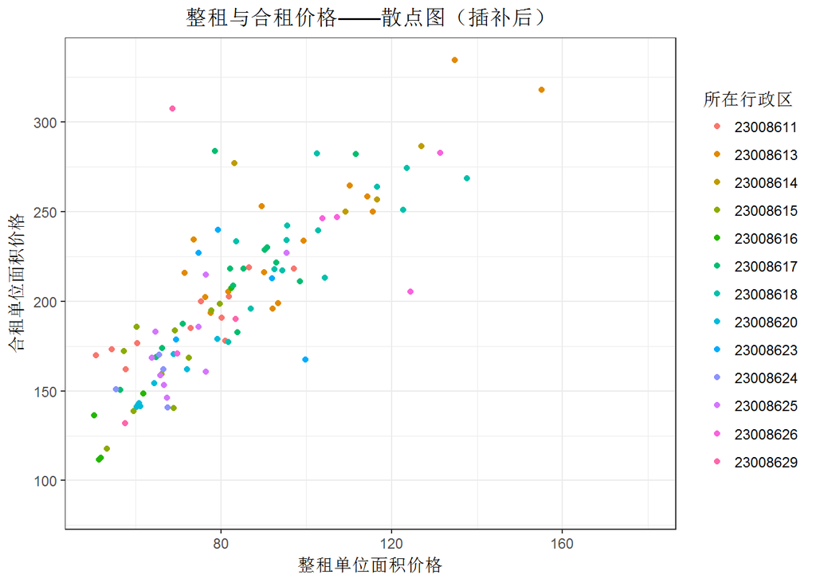

```r
ggplot(data = ziru2_rent_type_junjia,aes(x = zheng_mean,y=he_mean))+
 geom_point(aes(color = hdic_district_id))+
  labs(x='整租单位面积价格',y='合租单位面积价格',color = '所在行政区',title='整租与合租价格——散点图（插补后）')+
  scale_x_continuous(limits = c(50,180))+
  #scale_y_continuous(limits = c(50,400))+
  theme_bw()+
  scale_color_discrete()+
  theme(plot.title = element_text(hjust = 0.5))
```